# Fisseha Berhane

PhD Candidate, [Department of Earth and Planetary Sciences,](http://eps.jhu.edu/) [Johns Hopkins University](http://jhu.edu)

### Using linear and non-linear regression models to predict global temperature

In this post, I used different linear and non-linear (support vector machines, random forest, neural network and boosting) regression models to predict global average temperature anomaly. First, I did exploratory data analysis to understand the features and how they can be associated with global temperature then built predicitve models employing various machine learning techniques and assessed the importance of the various independet variables in predicting average global temperature anomaly. The data is aquaired from the MITX Analytics Edge edx course [Website.](https://courses.edx.org/asset-v1:MITx+15.071x_2a+2T2015+type@asset+block/climate_change.csv)

Let’s download the data and see the variables in the data set.

```r
# Load required libraries

library(downloader)
require(ggplot2)
library(caret)
library(nnet)
library(NeuralNetTools)

url<-"https://courses.edx.org/asset-v1:MITx+15.071x_2a+2T2015+type@asset+block/climate_change.csv"

download(url,dest="climate.csv")

clim = read.csv("climate.csv")

str(clim)
```

```
## 'data.frame':    308 obs. of  11 variables:
##  $ Year    : int  1983 1983 1983 1983 1983 1983 1983 1983 1984 1984 ...
##  $ Month   : int  5 6 7 8 9 10 11 12 1 2 ...
##  $ MEI     : num  2.556 2.167 1.741 1.13 0.428 ...
##  $ CO2     : num  346 346 344 342 340 ...
##  $ CH4     : num  1639 1634 1633 1631 1648 ...
##  $ N2O     : num  304 304 304 304 304 ...
##  $ CFC.11  : num  191 192 193 194 194 ...
##  $ CFC.12  : num  350 352 354 356 357 ...
##  $ TSI     : num  1366 1366 1366 1366 1366 ...
##  $ Aerosols: num  0.0863 0.0794 0.0731 0.0673 0.0619 0.0569 0.0524 0.0486 0.0451 0.0416 ...
##  $ Temp    : num  0.109 0.118 0.137 0.176 0.149 0.093 0.232 0.078 0.089 0.013 ...
```

Let’s use the data upto 2006 for training and predict for 2007 and 2008. We will not use the variables ‘Year’ and ‘Month’ in predicitive model building process.

```r
training<-subset(clim,clim$Year<=2006)
testing<-subset(clim,clim$Year > 2006)

testingX<-subset(clim[,3:10],clim$Year> 2006)
testingY<-subset(clim[,11],clim$Year> 2006)
```

### Exploratory Data Analysis

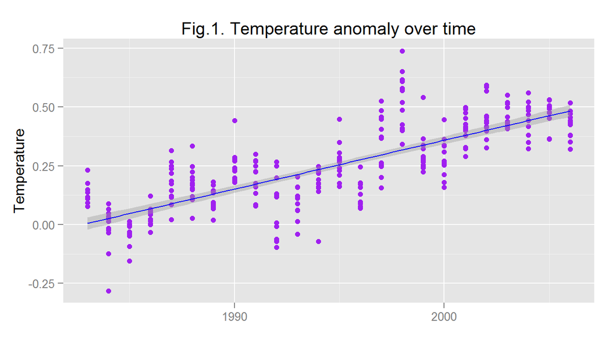

```r
ggplot(training, aes(Year, Temp))+geom_point(color="purple")+ggtitle('Fig.1. Temperature anomaly over time')+xlab('')+ylab('Temperature')+stat_smooth(method=lm, colour='blue',span=0.2)
```

From Fig.1., we see the clear increasing trend of temperature over the data period.

One of the main causes of global temperature increase is asscoaited with inceased carbondioxide emission to the atmosphere from different sources. Let’s see the relationship between temperature and carbondiodixe.

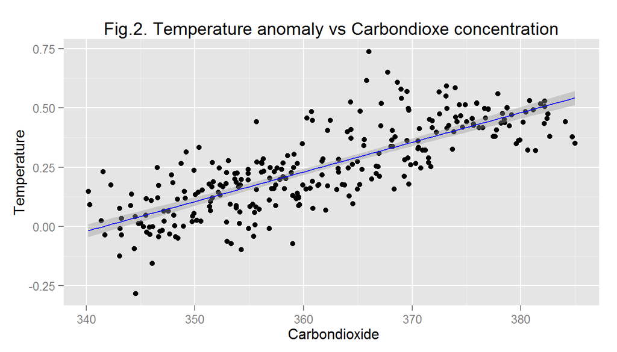

```r
ggplot(training, aes(CO2, Temp))+geom_point()+ggtitle('Fig.2. Temperature anomaly vs Carbondioxe concentration')+xlab(' Carbondioxide')+ylab('Temperature')+stat_smooth(method=lm,colour='blue', span=0.2)
```

As shown in Fig.2, carbondioxide and temperature are strongly related.

Following an oscillation in the tropical Pacific Ocean, global tempreature fluctuates. This ocillation is represented by the variable MEI in the dataset. Let’s plot the association of temperature anomaly with the MEI index.

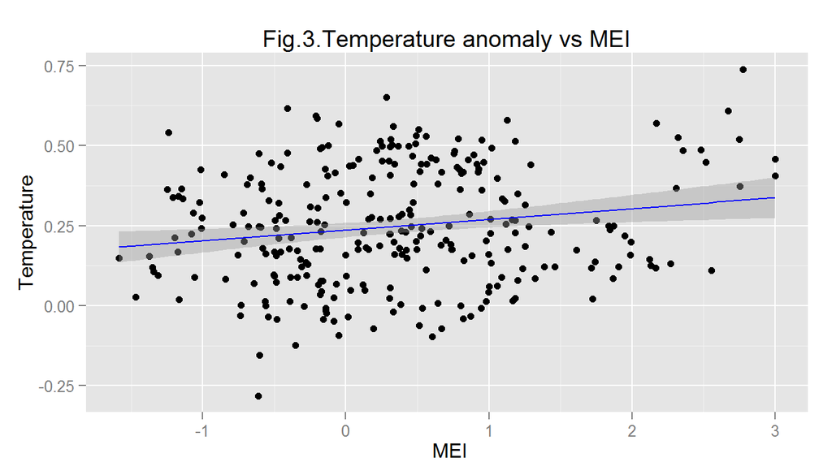

```r
ggplot(training, aes(MEI, Temp))+geom_point()+ggtitle('Fig.3.Temperature anomaly vs MEI')+xlab(' MEI')+ylab('Temperature')+stat_smooth(method=lm,colour='blue', span=0.2)
```

The figure does not reveal strong linear association between MEI and average global temperature, however, MEI can have systematic influences on global temperature and it could be an important predictor as we will see later.

### Linear Model

Let’s fit a generalized linear model with the “glm” function.

```r
model1<-glm(Temp~., family = gaussian, data=training[,3:11])
```

We can see the summary of the model, predict using the testing data and compare predictions with the observations.

```r
summary(model1)
```

```
##
## Call:
## glm(formula = Temp ~ ., family = gaussian, data = training[,
##     3:11])
##
## Deviance Residuals:
##      Min        1Q    Median        3Q       Max
## -0.25888  -0.05913  -0.00082   0.05649   0.32433
##
## Coefficients:
##               Estimate Std. Error t value Pr(>|t|)
## (Intercept) -1.246e+02  1.989e+01  -6.265 1.43e-09 ***
## MEI          6.421e-02  6.470e-03   9.923  < 2e-16 ***
## CO2          6.457e-03  2.285e-03   2.826  0.00505 **
## CH4          1.240e-04  5.158e-04   0.240  0.81015
## N2O         -1.653e-02  8.565e-03  -1.930  0.05467 .
## CFC.11      -6.631e-03  1.626e-03  -4.078 5.96e-05 ***
## CFC.12       3.808e-03  1.014e-03   3.757  0.00021 ***
## TSI          9.314e-02  1.475e-02   6.313 1.10e-09 ***
## Aerosols    -1.538e+00  2.133e-01  -7.210 5.41e-12 ***
## ---
## Signif. codes:  0 '***' 0.001 '**' 0.01 '*' 0.05 '.' 0.1 ' ' 1
##
## (Dispersion parameter for gaussian family taken to be 0.00841098)
##
##     Null deviance: 9.2853  on 283  degrees of freedom
## Residual deviance: 2.3130  on 275  degrees of freedom
## AIC: -540.2
##
## Number of Fisher Scoring iterations: 2
```

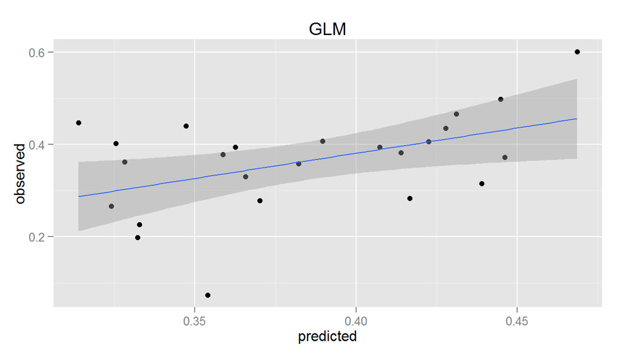

```r
pred<-predict(model1,testingX)

my_data=as.data.frame(cbind(predicted=pred,observed=testingY))

ggplot(my_data,aes(predicted,observed))+geom_point()+geom_smooth(method=lm)+ggtitle('GLM')
```

Now, let’s use the [step](https://stat.ethz.ch/R-manual/R-devel/library/stats/html/step.html) function to select important features automatically via Akaike Information Criterion (AIC).

```r
model2<-step(model1,k = 3.8415)
```

```
## Start:  AIC=-523.63
## Temp ~ MEI + CO2 + CH4 + N2O + CFC.11 + CFC.12 + TSI + Aerosols
##
##            Df Deviance     AIC
## - CH4       1   2.3135 -527.41
## - N2O       1   2.3443 -523.65
## <none>          2.3130 -523.63
## - CO2       1   2.3802 -519.34
## - CFC.12    1   2.4318 -513.25
## - CFC.11    1   2.4529 -510.80
## - TSI       1   2.6482 -489.04
## - Aerosols  1   2.7503 -478.29
## - MEI       1   3.1412 -440.55
##
## Step:  AIC=-527.41
## Temp ~ MEI + CO2 + N2O + CFC.11 + CFC.12 + TSI + Aerosols
##
##            Df Deviance     AIC
## - N2O       1   2.3448 -527.43
## <none>          2.3135 -527.41
## - CO2       1   2.3802 -523.18
## - CFC.12    1   2.4437 -515.70
## - CFC.11    1   2.4529 -514.64
## - TSI       1   2.6485 -492.85
## - Aerosols  1   2.7534 -481.82
## - MEI       1   3.1447 -444.08
##
## Step:  AIC=-527.43
## Temp ~ MEI + CO2 + CFC.11 + CFC.12 + TSI + Aerosols
##
##            Df Deviance     AIC
## <none>          2.3448 -527.43
## - CO2       1   2.3824 -526.76
## - CFC.12    1   2.4657 -517.00
## - CFC.11    1   2.4730 -516.16
## - TSI       1   2.6557 -495.92
## - Aerosols  1   2.8017 -480.72
## - MEI       1   3.1799 -444.75
```

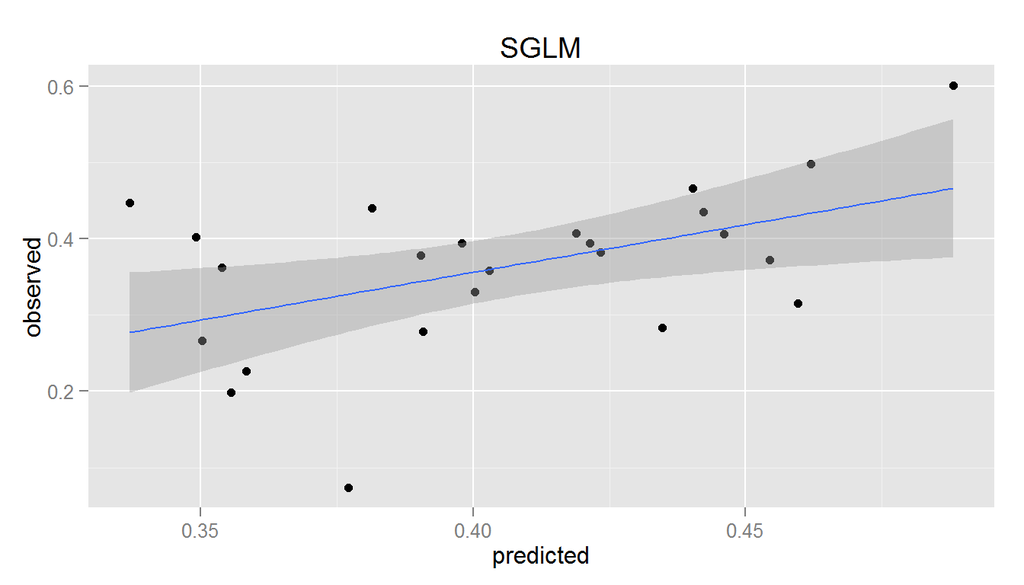

```r
pred<-predict(model2,testingX)

my_data=as.data.frame(cbind(predicted=pred,observed=testingY))

ggplot(my_data,aes(predicted,observed))+geom_point()+geom_smooth(method=lm)+ggtitle('SGLM')
```

The step function removed the variables CH4 (which is not significant predictor in model1 above) and N2O (which is significant at the 90% confidence level in model1 above).

We can also plot the importance of the features using repeated k-fold cross-validation with the caret package, one of my favorite R packages, along with ggplot2.

```r
control <- trainControl(method="repeatedcv", number=10, repeats=3)

# train the model

model <- train(Temp~., data=training[,3:11], method="glm", preProcess=c("center","scale"), trControl=control)

# estimate variable importance
importance <- varImp(model, scale=FALSE)
# summarize importance
print(importance)
```

```
## glm variable importance
##
##          Overall
## MEI       9.9232
## Aerosols  7.2103
## TSI       6.3126
## CFC.11    4.0778
## CFC.12    3.7573
## CO2       2.8264
## N2O       1.9297
## CH4       0.2405
```

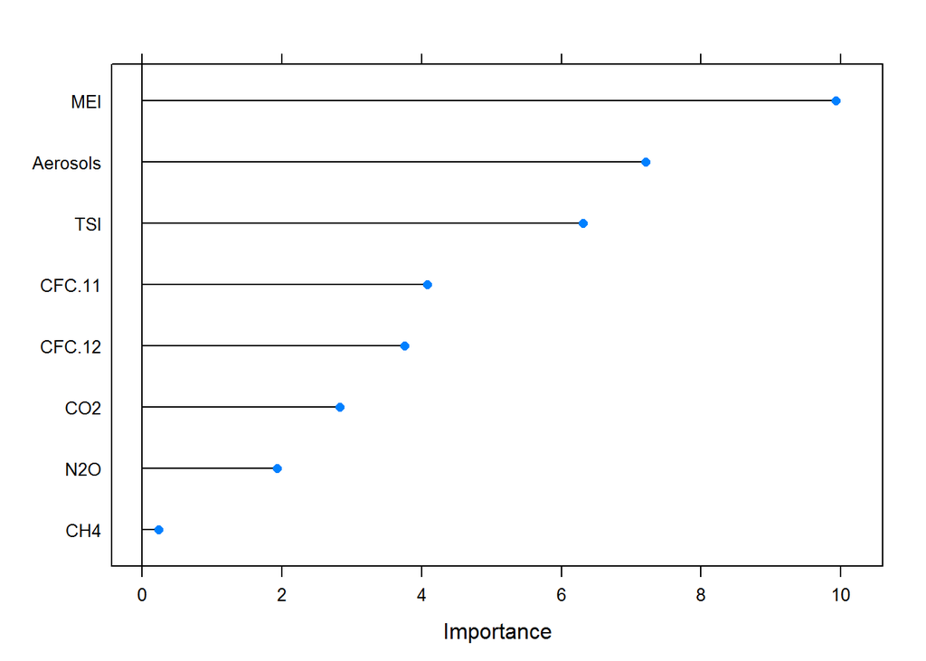

```r
# plot importance
plot(importance)
```

The [Recurssive Feature Eliminattion (RFE)](http://topepo.github.io/caret/rfe.html) function can also be used to automatically select important predictors. For example, let’s use RFE to select the important predictors for a random forest model and generalized linear model.

```r
# define the control using a random forest selection function

control <- rfeControl(functions=rfFuncs, method="cv", number=10)

# run the RFE algorithm

results <- rfe(training[,3:10], training[,11], sizes=c(1:8), rfeControl=control)

# summarize the results

print(results)
```

```
##
## Recursive feature selection
##
## Outer resampling method: Cross-Validated (10 fold)
##
## Resampling performance over subset size:
##
##  Variables    RMSE Rsquared   RMSESD RsquaredSD Selected
##          1 0.16152   0.2888 0.031455    0.20378
##          2 0.10328   0.6763 0.014701    0.07770
##          3 0.07564   0.8268 0.010331    0.03847
##          4 0.07338   0.8372 0.009251    0.03579
##          5 0.07098   0.8490 0.010348    0.03919
##          6 0.06868   0.8571 0.010150    0.03663
##          7 0.06817   0.8594 0.011077    0.04075
##          8 0.06728   0.8637 0.010510    0.03789        *
##
## The top 5 variables (out of 8):
##    CFC.11, MEI, CFC.12, N2O, Aerosols
```

```r
# list the chosen features

predictors(results)
```

```
## [1] "CFC.11"   "MEI"      "CFC.12"   "N2O"      "Aerosols" "TSI"
## [7] "CO2"      "CH4"
```

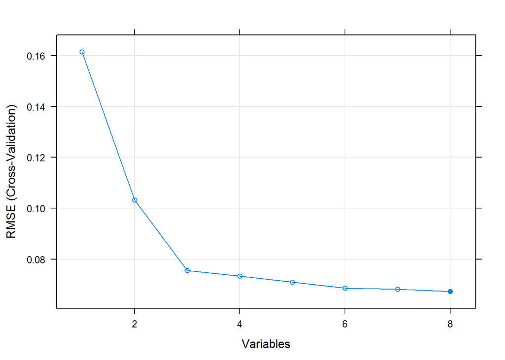

```r
# plot the results
plot(results, type=c("g", "o"))
```

Let’s see if the features selected for a generalized linear model using the RFE function are the same with those selected for the random forest model shown above.

```r
# define the control using a linear model selection function

control <- rfeControl(functions=lmFuncs, method="cv", number=10)

# run the RFE algorithm

results <- rfe(training[,3:10], training[,11], sizes=c(1:8), rfeControl=control)

# summarize the results

print(results)
```

```
##
## Recursive feature selection
##
## Outer resampling method: Cross-Validated (10 fold)
##
## Resampling performance over subset size:
##
##  Variables    RMSE Rsquared  RMSESD RsquaredSD Selected
##          1 0.17826  0.05114 0.01454    0.04211
##          2 0.16066  0.23025 0.01420    0.12429
##          3 0.14531  0.37729 0.01651    0.14428
##          4 0.13682  0.43643 0.01322    0.11391
##          5 0.09298  0.74696 0.01185    0.06101
##          6 0.09286  0.74867 0.01104    0.05819
##          7 0.09257  0.74921 0.01132    0.06417        *
##          8 0.09302  0.74654 0.01174    0.06573
##
## The top 5 variables (out of 7):
##    MEI, Aerosols, TSI, CFC.11, CFC.12
```

```r
# list the chosen features

predictors(results)
```

```
## [1] "MEI"      "Aerosols" "TSI"      "CFC.11"   "CFC.12"   "CO2"
## [7] "N2O"
```

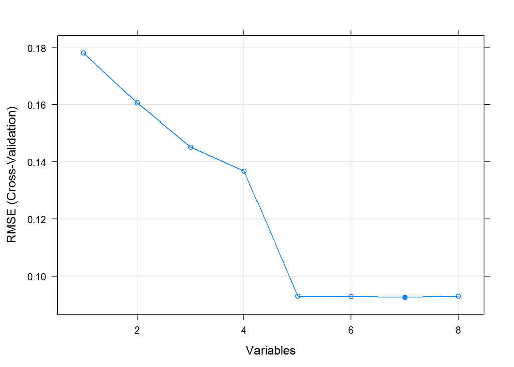

```r
# plot the results
plot(results, type=c("g", "o"))
```

### Non-linear regression models

Now, let’s work with non-linear regression models: neural network, support vector machines, random forest and boosting.

### Neural networks

To choose the number of hidden units and the amount of weight decay via resampling, the train function can be applied.

First, we remove predictors to ensure that the maximum absolute pairwise correlation between the predictors is less than 0.75.

```r
# The findCorrelation takes a correlation matrix and determines the column numbers that should be removed to keep all pair-wise correlations below a threshold

tooHigh <- findCorrelation(cor(training[,3:10]), cutoff = .75)

trainXnnet <- training[,3:10][, -tooHigh]
testXnnet <- testing[,3:10][, -tooHigh]

## Create a specific candidate set of models to evaluate:

nnetGrid <- expand.grid(.decay = seq(0, 0.1, .01),
.size = c(3:10),

## The next option is to use bagging
## instead of different random
## seeds.
.bag = FALSE)

 set.seed(100)

ctrl <- trainControl(method = "cv", number = 10)

nnetTune <- train(trainXnnet, training[,11],
method = "avNNet",repeats = 5,
tuneGrid = nnetGrid,
trControl = ctrl,
## Automatically standardize data prior to modeling and prediction
preProc = c("center", "scale"),
linout = TRUE,
trace = FALSE,
MaxNWts = 10 * (ncol(trainXnnet) + 1) + 10 + 1,
maxit = 500)
```

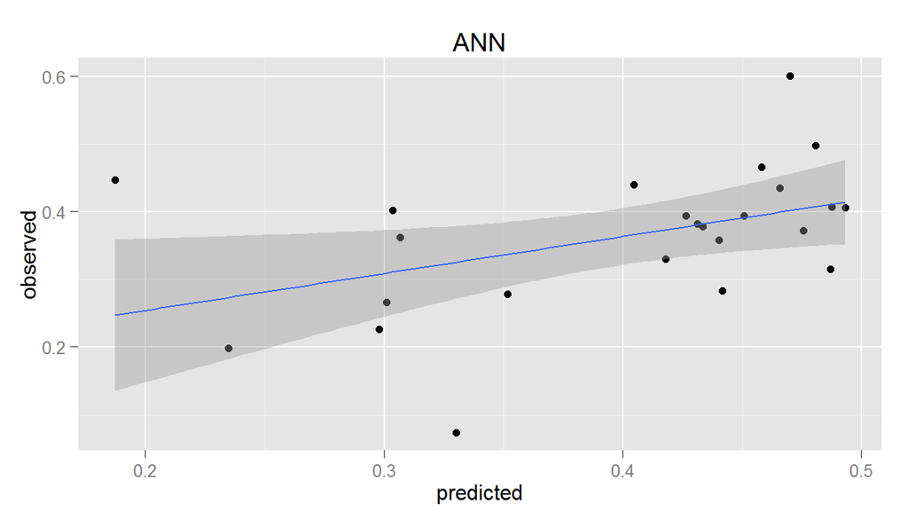

```r
pred<-predict(nnetTune,testXnnet)

my_data=as.data.frame(cbind(predicted=pred,observed=testingY))

ggplot(my_data,aes(predicted,observed))+geom_point()+geom_smooth(method=lm)+ggtitle('ANN')
```

Now let’s visualize the neural nets used for averagig.

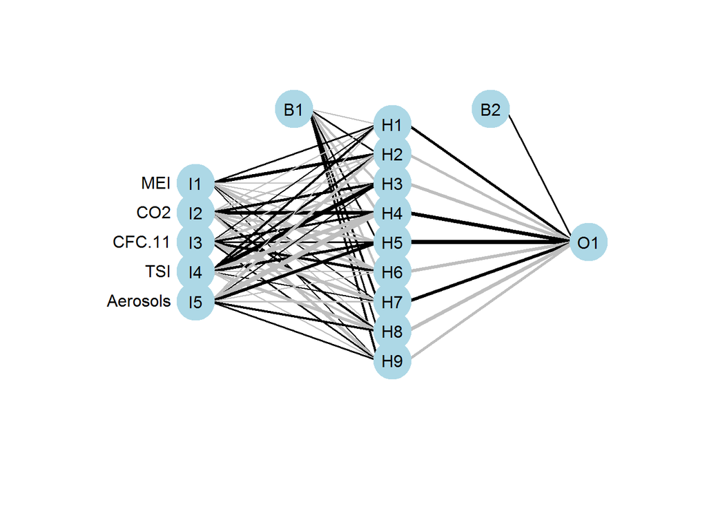

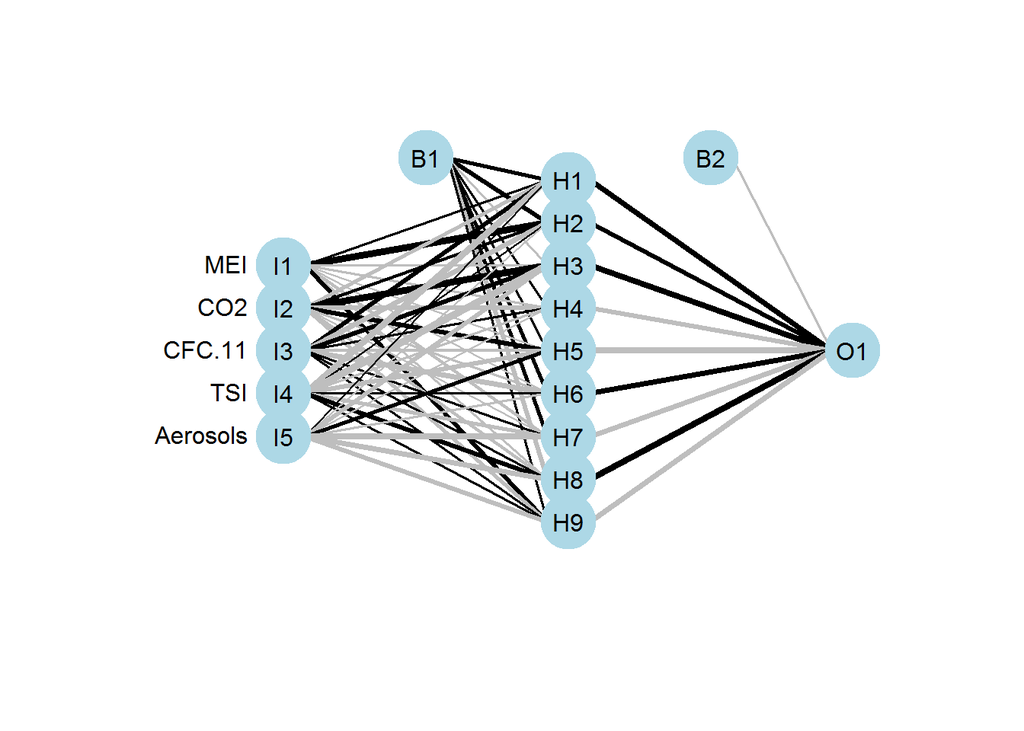

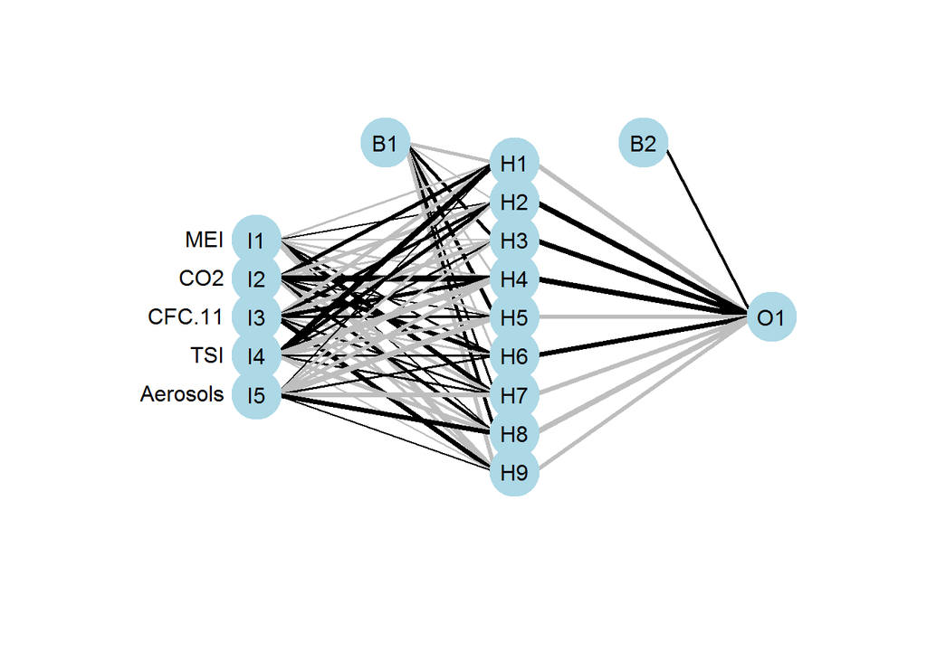

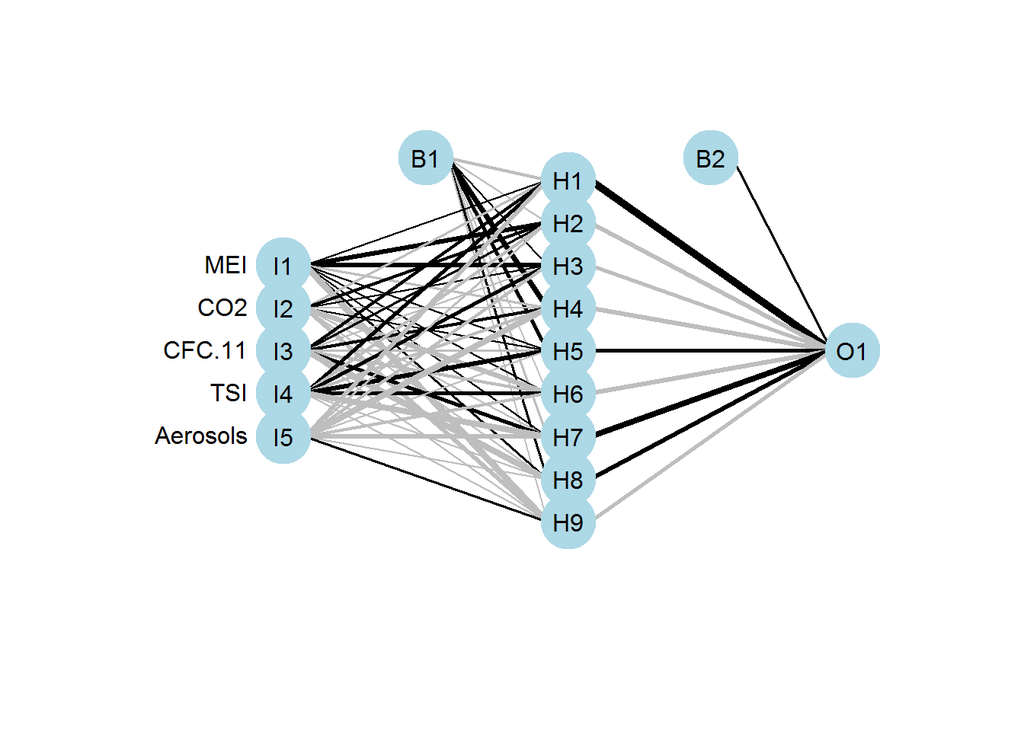

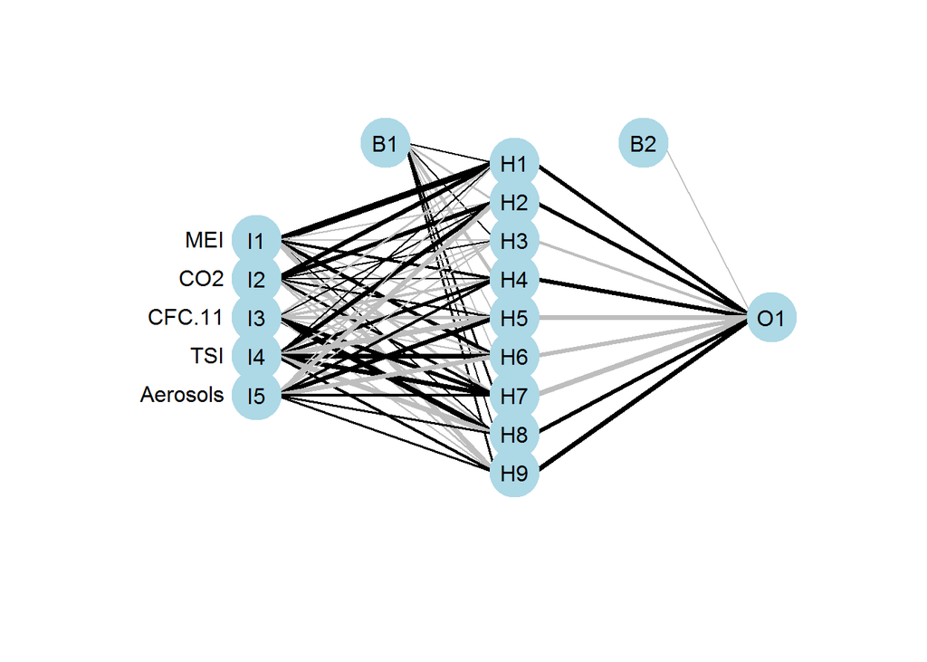

```r
for (i in 1:length(nnetTune$finalModel$model))
     {
allmods <- nnetTune$finalModel$model

mod <- allmods[[i]] # first model, change this number to look at the other models

wts <- mod$wts
decay <- mod$decay
struct <- mod$n

# recreate
recmod <- nnet(trainXnnet, training[,11], Wts = wts, decay = decay, size = struct[2], maxit = 0)

# use the functions to look at the individual model

plotnet(recmod)

}
```

In the above figures, the black (gray) lines correspond to positive (negative) weights.

### Support Vector Machines

There are a couple of options to work with support vector machines for regression. The details can be found from the [caret](http://topepo.github.io/caret/Support_Vector_Machines.html) website.

Here, let’s use support vector machines with radial basis function kernel.

```r
svmRTuned <- train(training[,3:10], training[,11],
method = "svmRadial",
preProc = c("center", "scale"),
tuneLength = 14,
trControl = trainControl(method = "cv",number=10))
```

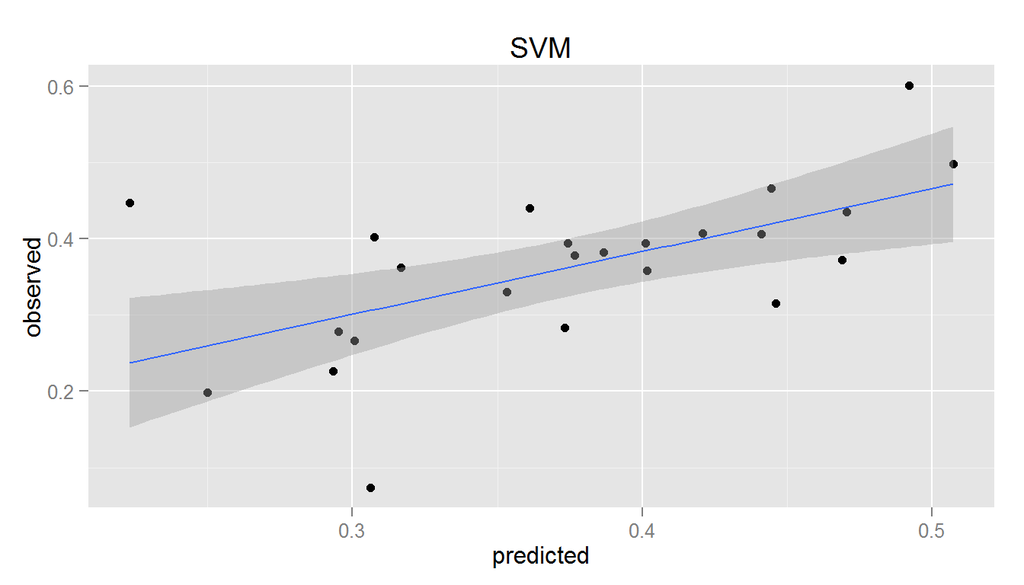

```r
pred<-predict(svmRTuned,testingX)

my_data=as.data.frame(cbind(predicted=pred,observed=testingY))

ggplot(my_data,aes(predicted,observed))+geom_point()+geom_smooth(method=lm)+ggtitle('SVM')
```

### Random Forest

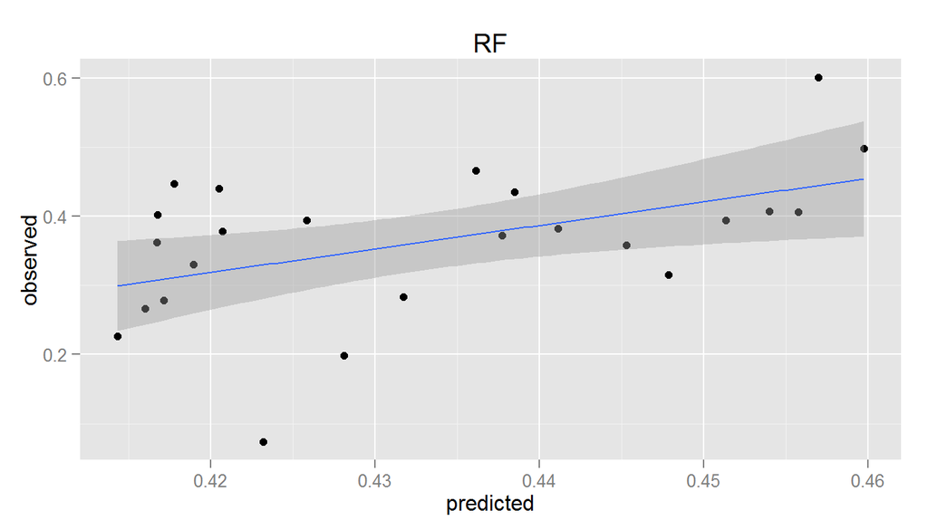

```r
rfTuned <- train(training[,3:10], training[,11],
method = "rf",
preProc = c("center", "scale"),

trControl = trainControl(method = "cv",number=10))

pred<-predict(rfTuned,testingX)

my_data=as.data.frame(cbind(predicted=pred,observed=testingY))

ggplot(my_data,aes(predicted,observed))+geom_point()+geom_smooth(method=lm)+ggtitle('RF')
```

### Boosting

```r
boostingTuned <- train(training[,3:10], training[,11],
method = "gbm",verbose=F,
preProc = c("center", "scale"),
trControl = trainControl(method = "cv",number=10))
```

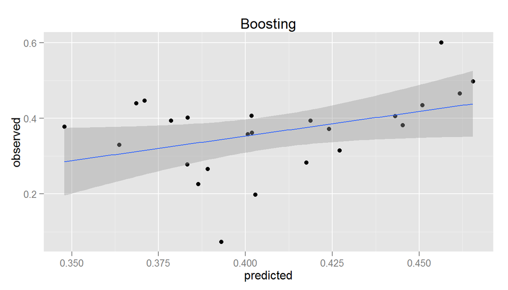

```r
pred<-predict(boostingTuned,testingX)

my_data=as.data.frame(cbind(predicted=pred,observed=testingY))

ggplot(my_data,aes(predicted,observed))+geom_point()+geom_smooth(method=lm)+ggtitle('Boosting')
```

We can use the caret package to compare the perfomance of the machine learning models we built using the train function from the caret library.

```r
# fit a glm using the features from the step function


glm_step <- train(training[,3:10], training[,11],
method = "glm",
preProc = c("center", "scale"),
trControl = trainControl(method = "cv",number=10))

results <- resamples(list(glm=glm_step,nnet=nnetTune, boosting=boostingTuned, rf=rfTuned, SVM=svmRTuned))
# summarize the distributions
summary(results)
```

```
##
## Call:
## summary.resamples(object = results)
##
## Models: glm, nnet, boosting, rf, SVM
## Number of resamples: 10
##
## RMSE
##             Min. 1st Qu.  Median    Mean 3rd Qu.    Max. NA's
## glm      0.07426 0.08336 0.08817 0.09182 0.10020 0.11540    0
## nnet     0.06333 0.06678 0.07195 0.07669 0.08592 0.09830    0
## boosting 0.05545 0.06726 0.07841 0.07568 0.08150 0.09369    0
## rf       0.04324 0.05976 0.06782 0.06748 0.07555 0.08843    0
## SVM      0.05399 0.06606 0.07704 0.07624 0.08737 0.09247    0
##
## Rsquared
##            Min. 1st Qu. Median   Mean 3rd Qu.   Max. NA's
## glm      0.6153  0.7129 0.7594 0.7502  0.8027 0.8274    0
## nnet     0.7309  0.7740 0.8332 0.8216  0.8602 0.9039    0
## boosting 0.7471  0.7984 0.8343 0.8290  0.8618 0.9098    0
## rf       0.7669  0.8490 0.8675 0.8665  0.8853 0.9443    0
## SVM      0.7237  0.7641 0.8455 0.8257  0.8761 0.9014    0
```

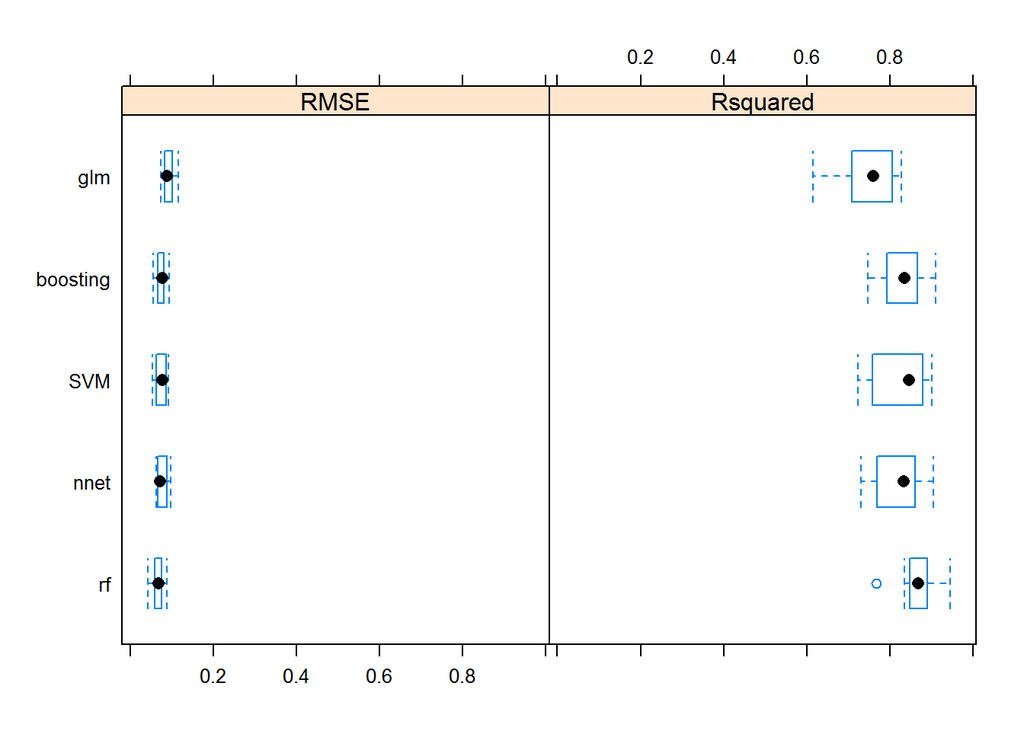

```r
# boxplots of results
bwplot(results)
```

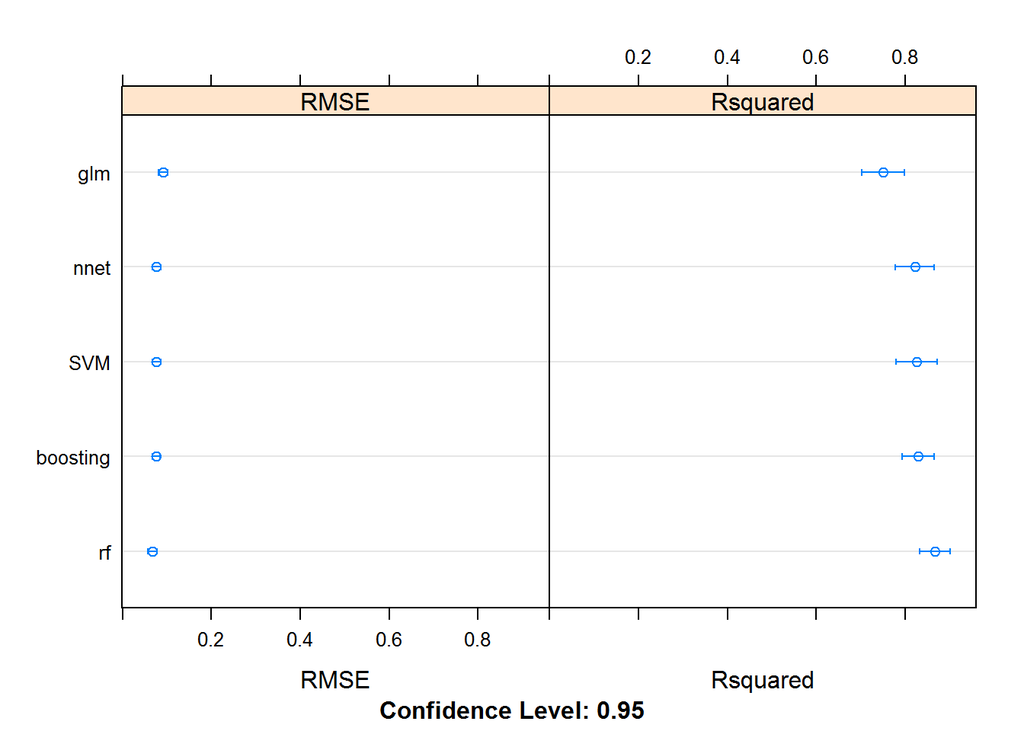

```r
# dot plots of results
dotplot(results)
```

Then, we can use different tests to assess if the performance of one model is significantly better than the others.

### Conclusion

In this project, the performance of non-linear regression models (support vector machines, neural network, boosting and random forest) in predicting average global temperature anomaly is compared with that of the simple generalized linear model. Generally, all considered models have similar performance but random forest has the highest R-squared value and least RMSE. Of course, to decide if random forest is significantly better than the other models in this application, hypothesis tests have to be implemented.